# Bike Sharing Dataset Exploration

## Preliminary Wrangling

> This data set includes information about individual rides made in a bike-sharing system covering the San Francisco Bay area.

```
Shape of Dataset is:  (183412, 16)
```

|  | duration_sec | start_time | end_time | start_station_id | start_station_name | start_station_latitude | start_station_longitude | end_station_id | end_station_name | end_station_latitude | end_station_longitude | bike_id | user_type | member_birth_year | member_gender | bike_share_for_all_trip |
| --- | --- | --- | --- | --- | --- | --- | --- | --- | --- | --- | --- | --- | --- | --- | --- | --- |
| 0 | 52185 | 2019-02-28 17:32:10.1450 | 2019-03-01 08:01:55.9750 | 21.0 | Montgomery St BART Station (Market St at 2nd St) | 37.789625 | -122.400811 | 13.0 | Commercial St at Montgomery St | 37.794231 | -122.402923 | 4902 | Customer | 1984.0 | Male | No |
| 1 | 42521 | 2019-02-28 18:53:21.7890 | 2019-03-01 06:42:03.0560 | 23.0 | The Embarcadero at Steuart St | 37.791464 | -122.391034 | 81.0 | Berry St at 4th St | 37.775880 | -122.393170 | 2535 | Customer | NaN | NaN | No |
| 2 | 61854 | 2019-02-28 12:13:13.2180 | 2019-03-01 05:24:08.1460 | 86.0 | Market St at Dolores St | 37.769305 | -122.426826 | 3.0 | Powell St BART Station (Market St at 4th St) | 37.786375 | -122.404904 | 5905 | Customer | 1972.0 | Male | No |
| 3 | 36490 | 2019-02-28 17:54:26.0100 | 2019-03-01 04:02:36.8420 | 375.0 | Grove St at Masonic Ave | 37.774836 | -122.446546 | 70.0 | Central Ave at Fell St | 37.773311 | -122.444293 | 6638 | Subscriber | 1989.0 | Other | No |
| 4 | 1585 | 2019-02-28 23:54:18.5490 | 2019-03-01 00:20:44.0740 | 7.0 | Frank H Ogawa Plaza | 37.804562 | -122.271738 | 222.0 | 10th Ave at E 15th St | 37.792714 | -122.248780 | 4898 | Subscriber | 1974.0 | Male | Yes |

### Structure of Dataset

This dataset includes 183,412 trips, with 16 features to describe them.

The Dataset's Features are:

- Trip Duration (seconds)
- Start Time
- End Time
- Start Station ID
- Start Station Name
- Stat Station Latitude
- Start Station Longtitude
- End Station ID
- End Station Name
- End Station Latitude
- End Station Longtitude
- Bike ID
- User Type
- Member Birth Year
- Member Gender
- Bike Sharing For All Trip
- The Start and End Times are in Date-Time format but their data type is string. Should be converted to Pandas Date-Time.
- A Rider's Birth Year is provided in the Dataset. We can use that to calculate their current age, in 2021.

### The main features of interest in this dataset

- What time of day are trips taking place?
- What locations are the busiest, and does time affect station traffic?
- What User Profiles (age, user_type, gender) are riding trips?
- Do different user profiles correspond to different trips? different times? Do they frequent different stations?
- Is bike sharing more common amongst certain ages?
- How long is the average trip?
- Does average trip time differ if user is a subscriber or customer?

### Features of the dataset that may support investigation into questions of interest

This is an awesome dataset with comprehensive features. All features of this dataset seem to be relevant to answering the questions posed above.

## Univariate Exploration

> In this section, we will investigate distributions of individual variables. Looking for outliers or anything that may seem usual to clean this dataset and prepare it for analysis and visualization.

## Let's have a look at the dataset's descriptive statistics

|  | duration_sec | start_station_id | start_station_latitude | start_station_longitude | end_station_id | end_station_latitude | end_station_longitude | bike_id | member_birth_year | age |
| --- | --- | --- | --- | --- | --- | --- | --- | --- | --- | --- |
| count | 183412.000000 | 183215.000000 | 183412.000000 | 183412.000000 | 183215.000000 | 183412.000000 | 183412.000000 | 183412.000000 | 175147.000000 | 175147.000000 |
| mean | 726.078435 | 138.590427 | 37.771223 | -122.352664 | 136.249123 | 37.771427 | -122.352250 | 4472.906375 | 1984.806437 | 36.193563 |
| std | 1794.389780 | 111.778864 | 0.099581 | 0.117097 | 111.515131 | 0.099490 | 0.116673 | 1664.383394 | 10.116689 | 10.116689 |
| min | 61.000000 | 3.000000 | 37.317298 | -122.453704 | 3.000000 | 37.317298 | -122.453704 | 11.000000 | 1878.000000 | 20.000000 |
| 25% | 325.000000 | 47.000000 | 37.770083 | -122.412408 | 44.000000 | 37.770407 | -122.411726 | 3777.000000 | 1980.000000 | 29.000000 |
| 50% | 514.000000 | 104.000000 | 37.780760 | -122.398285 | 100.000000 | 37.781010 | -122.398279 | 4958.000000 | 1987.000000 | 34.000000 |
| 75% | 796.000000 | 239.000000 | 37.797280 | -122.286533 | 235.000000 | 37.797320 | -122.288045 | 5502.000000 | 1992.000000 | 41.000000 |
| max | 85444.000000 | 398.000000 | 37.880222 | -121.874119 | 398.000000 | 37.880222 | -121.874119 | 6645.000000 | 2001.000000 | 143.000000 |

```
count    175147.000000
mean         36.193563
std          10.116689
min          20.000000
25%          29.000000
50%          34.000000
75%          41.000000
max         143.000000
Name: age, dtype: float64
```

We observe that the average age of users is 36.19. The max, however is 143.

There may have been some mistakes in a small number of the user ages. We also observe that some members don't have a birth year and are marked as NaN.

### We remove outlier users over the age 105

### Now, what is the average age of users?

```
The average age of bike riders in this dataset is now 36.158777666714265
```

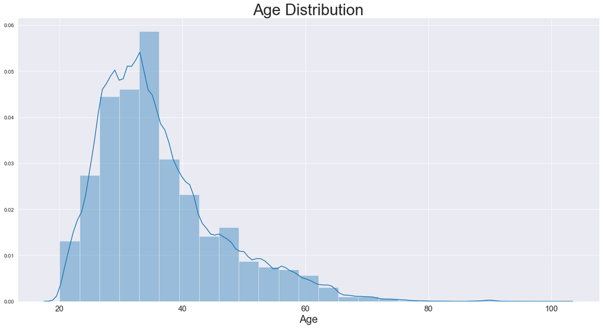

> We see that the data is positively skewed with some outliers around the higher age. Most of our dataset's users are under the age of 60. The 75th percentile is age 41.

### What is the average trip time?

```
The average Trip Time is 11.74 minutes
```

```
4998
```

## Violin Plot

### After Removing Outliers (only for the purposes of this plot).

#### Plotting All rides under 5K Seconds.

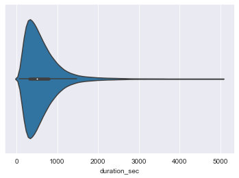

## What are the top 5 stations where trips started?

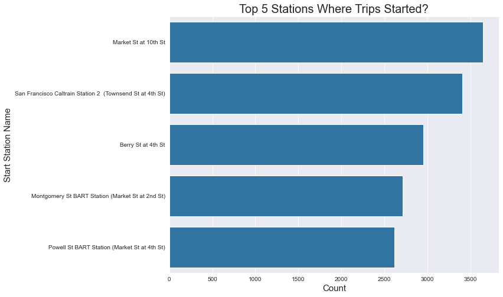

### What are the Types of Users in the dataset?

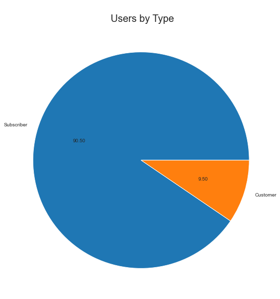

**We can see that 90.5% of our users are Subscribers. Only 9.5% are Customers.**

### What about Gender of users in the dataset?

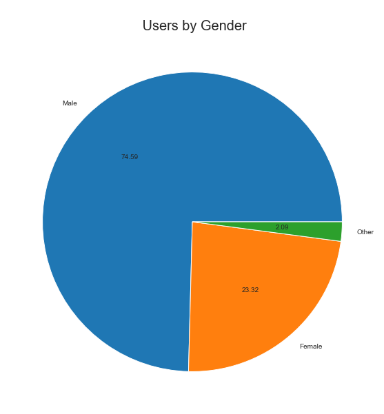

**We can see that 74.59% of our users are Male. 23.32% are Female. And 2.09% self-identify as Other.**

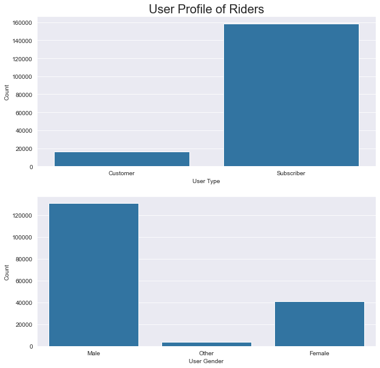

## What is the distribution of Bike Ride Duration in Minutes?

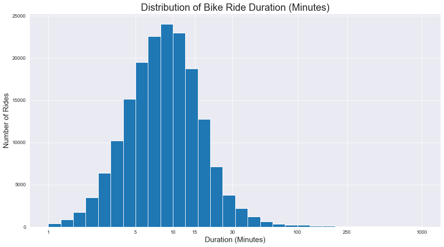

## Bivariate Exploration

> In this section we ivnestigate relationships between pairs of variables.

### What is the relationship between Age and Ride Duration?

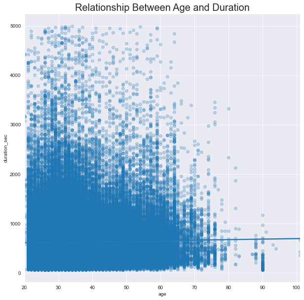

### What do trips look like when grouped by riders' features?

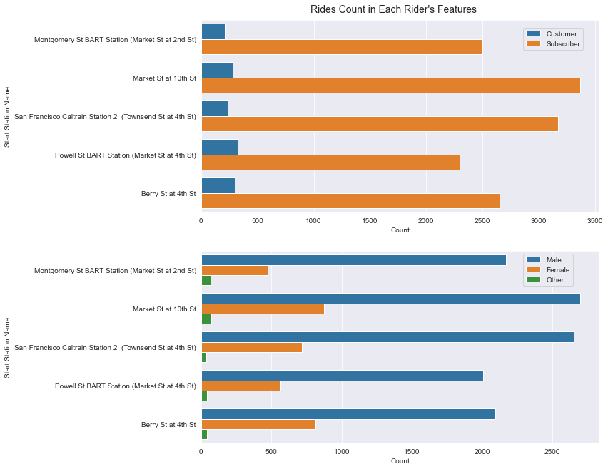

## What is the duration of rides for each month in the dataset?

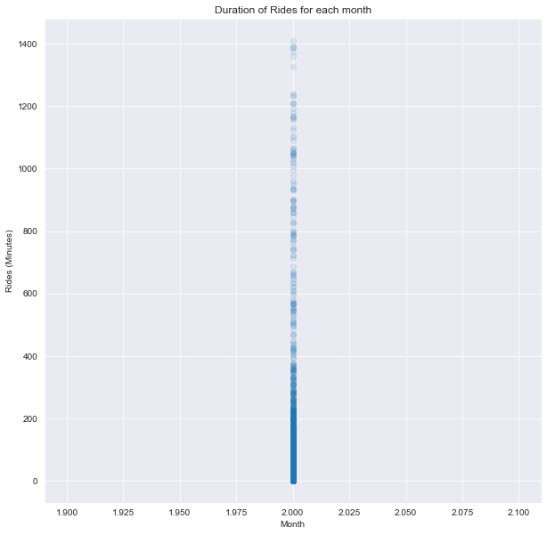

**Oddly, all trips seem to be in the month of February. This seems to be the dataset for one month of rides only.**

```
array([2], dtype=int64)
```

#### **Indeed, they are.**

## Multivariate Exploration

> Creating a plot that investigates 3 or more variables in the dataset.

## How is the average trip time affected by Gender and User Type?

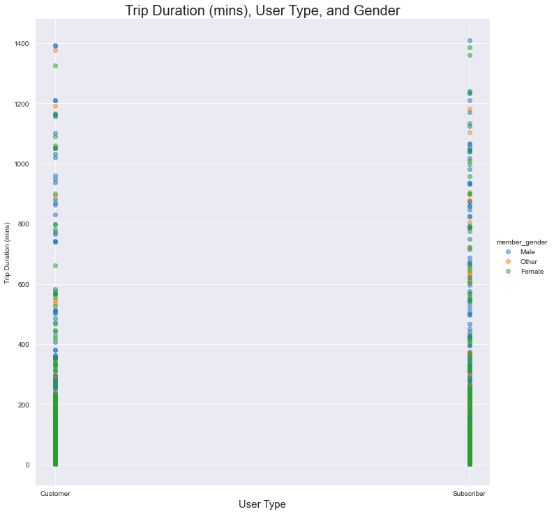

## Conclusion

We also further validate the findings from Univariate Explorations here.

1. Multivariate exploration: Segmenting users by their features helps gain insight into the dataset. We discovered that this dataset pertains to only one month of the year. Popular areas, logically, have much higher traffic. There is no clear explanation to why Male riders and significantly more than Female riders. We notice however that most female rides are under 200 minutes.

The stations with the most trips are located in San Francisco and connect to public transportations such as Market St, Caltrain, and Berry St, and Montgomery St Bart.